# Learning What Drives Nightly Price on Airbnb

Cesar Aguilar

2026-09-09

## Link to Data Source

Source: Inside Airbnb https://insideairbnb.com/get-the-data/ File used: https://data.insideairbnb.com/united-states/nc/asheville/2026-06-25/data/listings.csv.gz

**My question:** which things that a host actually controls affect the nightly price of a listing?

**Hypothesis:** Listings that sleep more guests charge higher nightly prices.

**Null hypothesis:** Guest capacity has no relationship with nightly price.

## Load Dataset

```r
listings <- read.csv("listings.csv", stringsAsFactors = FALSE)

# Room type counts before cleaning, so I can compare after
table(listings$room_type)
```

```
##
## Entire home/apt      Hotel room    Private room     Shared room
##            2599               2             256               8
```

```r
# price_quote_price_per_night is already a number. The plain price column
# loads as text and cannot be used for math.
listings$price_num <- listings$price_quote_price_per_night

d <- listings[, c("price_num", "accommodates", "bedrooms",
                  "review_scores_rating", "minimum_nights", "room_type")]

d <- na.omit(d)

# Drop a few extreme prices above $2,000
d <- subset(d, price_num > 0 & price_num <= 2000)

nrow(d)
```

```
## [1] 2202
```

```r
head(d)
```

```
##   price_num accommodates bedrooms review_scores_rating minimum_nights
## 1    116.00            2        1                 4.63              1
## 4    104.00            4        1                 4.89             30
## 6    210.00            2        1                 4.98              2
## 7    171.18            3        1                 4.99              1
## 8    266.00            2        1                 4.82              1
## 9    200.00            4        1                 4.76              1
##         room_type
## 1 Entire home/apt
## 4 Entire home/apt
## 6 Entire home/apt
## 7 Entire home/apt
## 8 Entire home/apt
## 9 Entire home/apt
```

After cleaning I have 2,202 listings left out of the original 2,865.

## Question 1: Visualizing the Data

I plotted price against number of bedrooms, since bedrooms is one of the first things a host decides on.

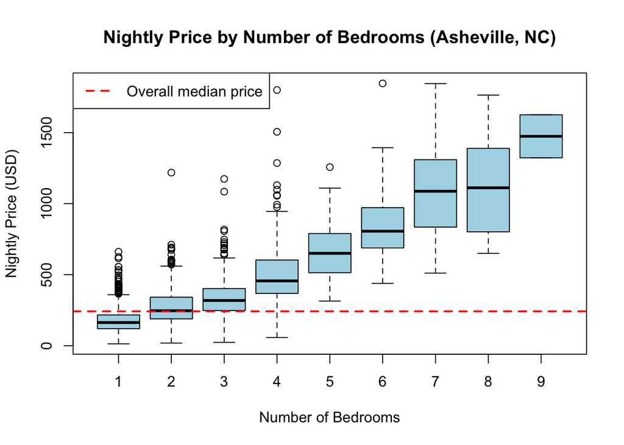

```r
boxplot(price_num ~ bedrooms, data = d,
        main = "Nightly Price by Number of Bedrooms (Asheville, NC)",
        xlab = "Number of Bedrooms",
        ylab = "Nightly Price (USD)",
        col = "lightblue")

abline(h = median(d$price_num), col = "red", lty = 2, lwd = 2)
legend("topleft", legend = "Overall median price",
       col = "red", lty = 2, lwd = 2)
```

## Question 2: Simple Statistical Calculation

My question is about price, so I started with the basic stats for price.

```r
mean(d$price_num)
```

```
## [1] 302.6121
```

```r
median(d$price_num)
```

```
## [1] 241.835
```

```r
sd(d$price_num)
```

```
## [1] 221.9477
```

**Explanation:** The mean price is $302.61 and the median is $241.84. The mean is about $60 higher than the median, which means a few expensive listings are pulling the average up. So the median is the better number to describe a typical Asheville listing. The standard deviation is $221.95, which is almost as big as the median, so prices are very spread out. That spread is useful for my question because it means there is a lot of room between a cheap listing and an expensive one. This sets up my hypothesis, since if guest capacity really drives price, then capacity should explain a good chunk of that $221.95 spread.

## Question 3: Correlation and Regression

I tested whether the number of guests a listing sleeps is related to price.

```r
cor.test(d$accommodates, d$price_num)
```

```
##
##  Pearson's product-moment correlation
##
## data:  d$accommodates and d$price_num
## t = 56.132, df = 2200, p-value < 2.2e-16
## alternative hypothesis: true correlation is not equal to 0
## 95 percent confidence interval:
##  0.7496189 0.7840036
## sample estimates:
##       cor
## 0.7673623
```

```r
model1 <- lm(price_num ~ accommodates, data = d)
summary(model1)
```

```
##
## Call:
## lm(formula = price_num ~ accommodates, data = d)
##
## Residuals:
##     Min      1Q  Median      3Q     Max
## -416.78  -80.42  -17.60   49.69 1364.84
##
## Coefficients:
##              Estimate Std. Error t value Pr(>|t|)
## (Intercept)   38.3285     5.6009   6.843    1e-11 ***
## accommodates  49.6039     0.8837  56.132   <2e-16 ***
## ---
## Signif. codes:  0 '***' 0.001 '**' 0.01 '*' 0.05 '.' 0.1 ' ' 1
##
## Residual standard error: 142.3 on 2200 degrees of freedom
## Multiple R-squared:  0.5888, Adjusted R-squared:  0.5887
## F-statistic:  3151 on 1 and 2200 DF,  p-value: < 2.2e-16
```

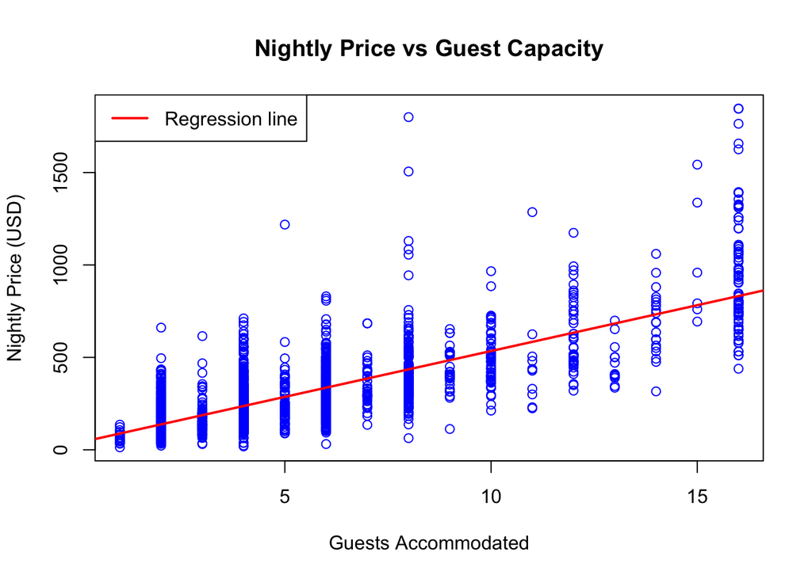

```r
plot(d$accommodates, d$price_num,
     main = "Nightly Price vs Guest Capacity",
     xlab = "Guests Accommodated",
     ylab = "Nightly Price (USD)",
     col = "blue")

abline(model1, col = "red", lwd = 2)
legend("topleft", legend = "Regression line", col = "red", lwd = 2)
```

**Explanation:** The correlation is r = 0.767 and the p value is below 2.2e-16, so the relationship is strong and not random. The R squared is 0.589, meaning guest capacity by itself explains about 59% of the price difference between listings. The slope says each extra guest a listing sleeps is worth about $49.60 more per night.Capacity is the biggest lever a host has.

### Comparing p values across variables

I loaded four numeric columns, so I ran the same correlation test on each one against price

```r
test1 <- cor.test(d$accommodates, d$price_num)
test2 <- cor.test(d$bedrooms, d$price_num)
test3 <- cor.test(d$review_scores_rating, d$price_num)
test4 <- cor.test(d$minimum_nights, d$price_num)

results <- data.frame(
  variable = c("accommodates", "bedrooms", "review_scores_rating",
               "minimum_nights"),
  correlation = c(test1$estimate, test2$estimate,
                  test3$estimate, test4$estimate),
  p_value = c(test1$p.value, test2$p.value,
              test3$p.value, test4$p.value)
)

results
```

```
##               variable correlation      p_value
## 1         accommodates  0.76736234 0.000000e+00
## 2             bedrooms  0.74516673 0.000000e+00
## 3 review_scores_rating  0.06169816 3.775538e-03
## 4       minimum_nights -0.20015028 2.472575e-21
```

## Question 4: Histogram and Distribution

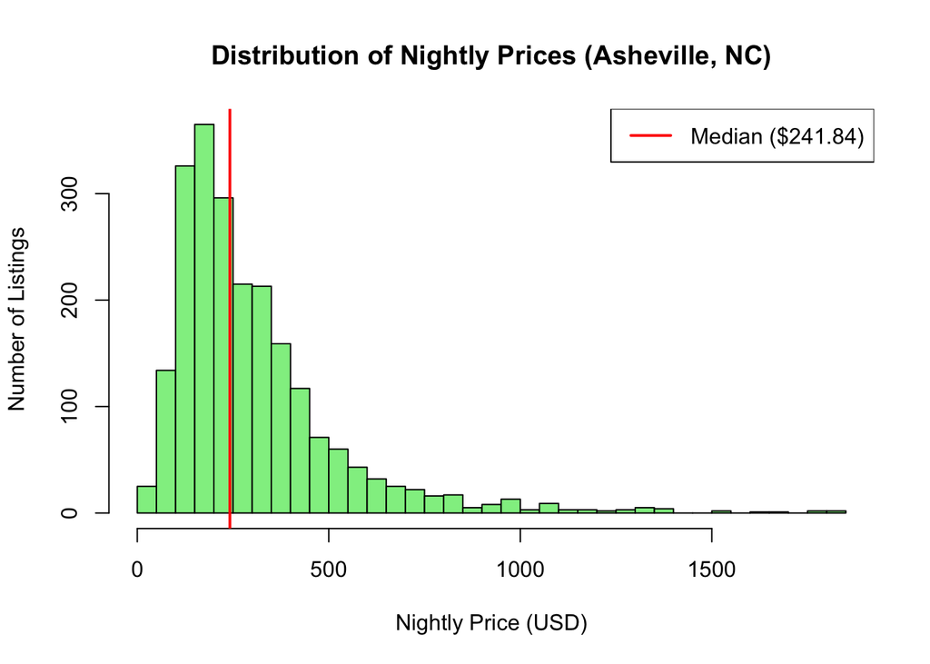

```r
hist(d$price_num,
     breaks = 40,
     main = "Distribution of Nightly Prices (Asheville, NC)",
     xlab = "Nightly Price (USD)",
     ylab = "Number of Listings",
     col = "lightgreen")

abline(v = median(d$price_num), col = "red", lwd = 2)
legend("topright", legend = "Median ($241.84)", col = "red", lwd = 2)
```

**Explanation:** This is right skewed. Most listings are between about $100 and $350, and then there is a long tail going out toward $2,000. This matches question 2, where the mean was higher than the median. This matters because a t test works best on data that is roughly normal. Taking the log of price fixes the shape:

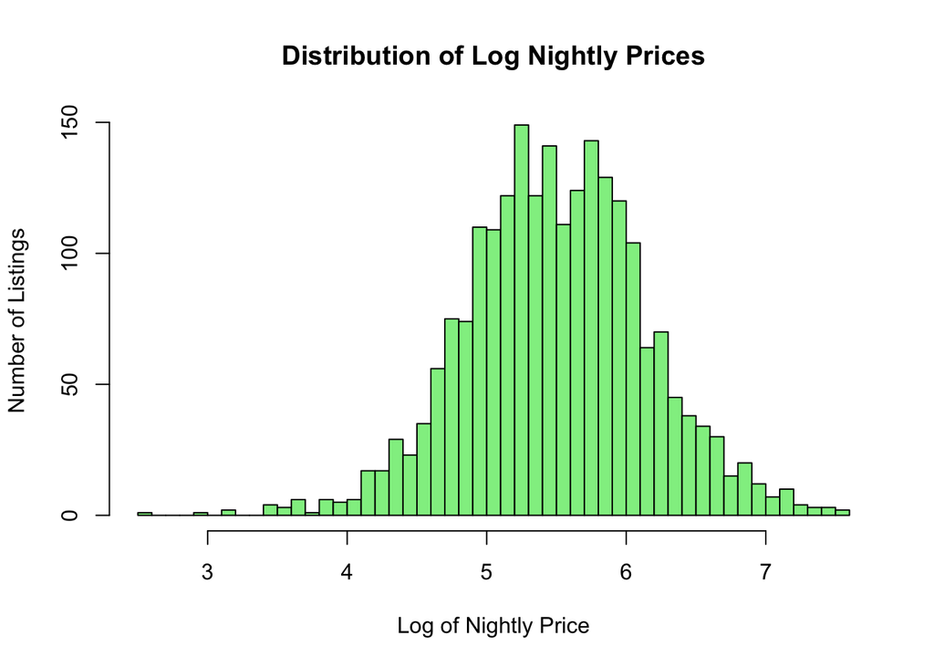

```r
d$logprice <- log(d$price_num)

hist(d$logprice,
     breaks = 40,
     main = "Distribution of Log Nightly Prices",
     xlab = "Log of Nightly Price",
     ylab = "Number of Listings",
     col = "lightgreen")
```

## Question 5: Two Group Test

I split the listings into entire homes and private rooms. This matters for my question because listing a whole unit or just a room is a choice the host makes.

```r
table(d$room_type)
```

```
##
## Entire home/apt      Hotel room    Private room     Shared room
##            2110               2              82               8
```

```r
two_groups <- subset(d, room_type == "Entire home/apt" | room_type == "Private room")

aggregate(price_num ~ room_type, data = two_groups, FUN = median)
```

```
##         room_type price_num
## 1 Entire home/apt   247.750
## 2    Private room   124.195
```

```r
# t test on log price, since question 4 showed raw price is skewed
t.test(logprice ~ room_type, data = two_groups)
```

```
##
##  Welch Two Sample t-test
##
## data:  logprice by room_type
## t = 8.0986, df = 86.403, p-value = 3.25e-12
## alternative hypothesis: true difference in means between group Entire home/apt and group Private room is not equal to 0
## 95 percent confidence interval:
##  0.4720283 0.7791242
## sample estimates:
## mean in group Entire home/apt    mean in group Private room
##                      5.529856                      4.904280
```

**Explanation:** After cleaning there are 2,110 entire homes and only 82 private rooms, down from 256 in the raw file, so a lot of private rooms were missing bedroom counts or review scores. The medians are $247.75 and $124.20, so entire homes are about double. I used a t test on log price because question 4 showed raw price is skewed. The result is t = 8.10 and p = 3.25e-12, so the difference is real. The difference in log means is 0.626, and exp(0.626) is about 1.87, so entire homes charge roughly 87% more per night than private rooms. That fits the rest of my results, since an entire home is basically a bigger unit with more capacity.

## Conclusion

Guest capacity alone explains about 59% of the price difference between listings, each extra guest is worth around $49.60 a night, and entire homes charge close to double what private rooms do. If you already have the unit, the levers are adding a sleeping spot and listing the whole place instead of a room. Review scores did not show to be as important since its correlation with price was only 0.062 even though the test called it significant. One thing to keep in mind is that only 82 private rooms were left after cleaning, so that last comparison is based on a small group.